# team

### 2

```r
Brock <- offCleanest %>% filter(Name == "Purdy, Brock")
str(Brock)
```

```
## tibble [72 x 4] (S3: tbl_df/tbl/data.frame)
##  $ Name    : Factor w/ 16 levels "Akers, Landen",..: 13 13 13 13 13 13 13 13 13 13 ...
##  $ Opponent: Factor w/ 11 levels "Baylor","Kansas",..: 4 4 4 4 4 4 8 8 8 8 ...
##  $ stat    : Factor w/ 9 levels "Passing_INT",..: 7 9 8 3 2 1 7 9 8 3 ...
##  $ value   : num [1:72] 7 35 0 145 0 1 8 6 0 211 ...
```

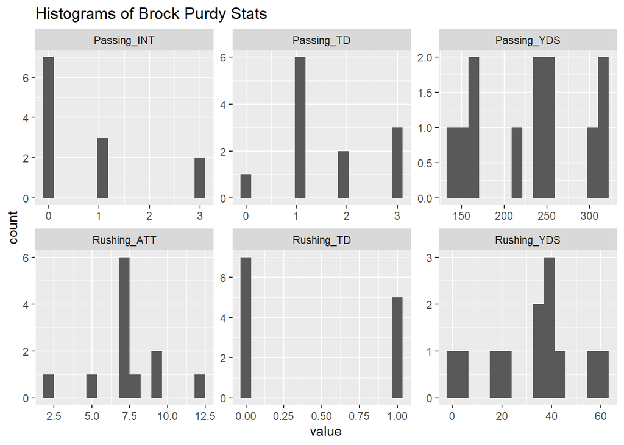

```r
ggplot(Brock, aes(x=value))+geom_histogram(bins = 15)+facet_wrap(~ stat, scales = 'free')+ggtitle("Histograms of Brock Purdy Stats")
```

As these histograms show, Brock Purdy is responsible for statistics in passing interceptions, passing touchdowns, passing yards (including many of the outliers seen in the overall data frame), rushing attempts, rushing touchdowns, and rushing yards.

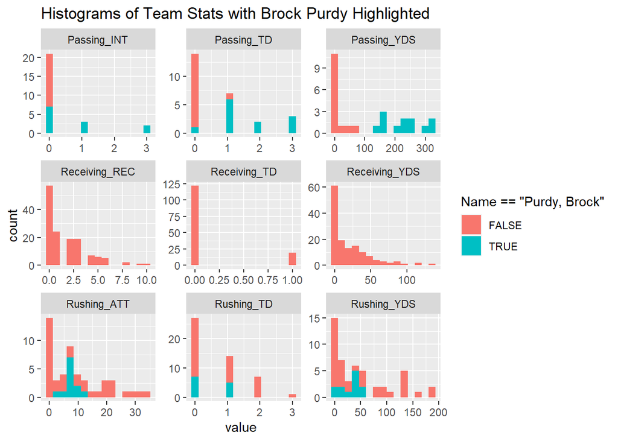

```r
ggplot(offCleanest, aes(x=value, fill=Name=="Purdy, Brock"))+geom_histogram(bins = 15)+facet_wrap(~ stat, scales = 'free')+ggtitle("Histograms of Team Stats with Brock Purdy Highlighted")
```

As shown in the graphs above, Brock Purdy’s statistics account for most of the passing yards, passing interceptions, and passing touchdowns, and a decent amount of rushing attempts, rushing touchdowns, and rushing yards. Therefore, Brock Purdy has a large impact on how the overall offense performs as he is the one that contributes to a lot of the major statistics.

### 3

```r
offense19 <- read_excel('../ds202_lab4/cyclonesFootball2019.xlsx', sheet='Offensive')

offense19 <- rename(offense19, 'Opponent'='Opponent_Opponent')
offense19$Opponent <- as.factor(offense19$Opponent)
offense19$Name <- as.factor(offense19$Name)

offense19 <- offense19 %>%
  mutate(across(Rushing_ATT:Passing_INT, as.numeric))
offClean19 <- offense19

offCleanLonger19 <- offClean19 %>%
  pivot_longer(Rushing_ATT:Passing_INT, names_to = 'stat',values_to = 'value' )

offCleanest19 <- drop_na(offCleanLonger19)

offAvg <- offCleanest %>%
  group_by(Name, stat)%>%
  summarise_at(vars(value), list(average20 = mean))

offAvg19 <- offCleanest19 %>%
  group_by(Name, stat)%>%
  summarise_at(vars(value), list(average19 = mean))

off1920 <- offAvg %>%
  left_join(offAvg19, by=c('Name', 'stat')) %>%
  drop_na() %>%
  mutate(difference = average20 - average19) %>%
  mutate(improved = difference>0)

head(off1920, 5)
```

```
## # A tibble: 5 x 6
## # Groups:   Name [2]
##   Name          stat          average20 average19 difference improved
##   <fct>         <chr>             <dbl>     <dbl>      <dbl> <lgl>
## 1 Akers, Landen Receiving_REC    1.5        0.692     0.808  TRUE
## 2 Akers, Landen Receiving_TD     0.0833     0         0.0833 TRUE
## 3 Akers, Landen Receiving_YDS   22.4        8.38     14.0    TRUE
## 4 Allen, Chase  Receiving_REC    1.73       1.31      0.420  TRUE
## 5 Allen, Chase  Receiving_TD     0.182      0.154     0.0280 TRUE
```

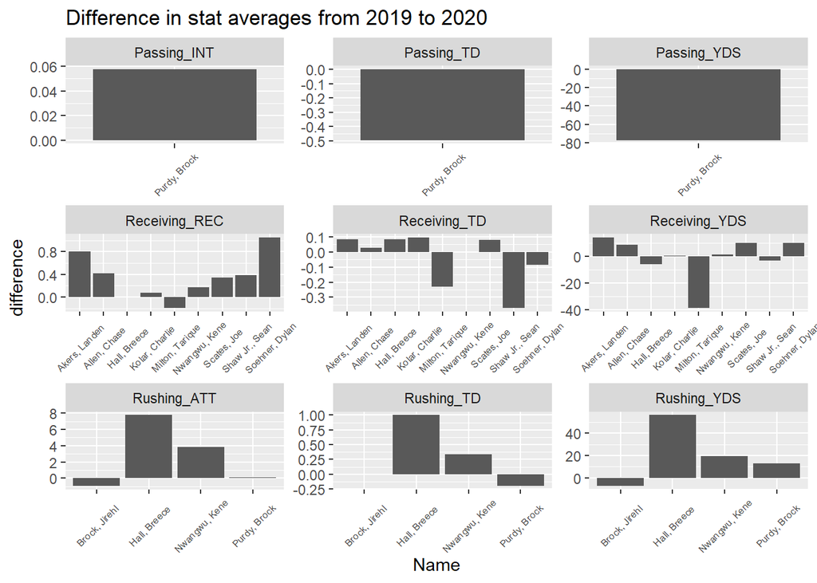

```r
ggplot(off1920, aes(x=Name, y=difference))+
  geom_bar(stat = "identity")+
  facet_wrap(~stat, scales = 'free')+
  ggtitle("Difference in stat averages from 2019 to 2020") +
  theme(axis.text.x = element_text(angle = 45, vjust = 0.5, hjus=0.5, size = rel(0.7)))
```

For this question I looked at the averages for each statistic on the offensive side of the ball for each player that played in both 2019 and 2020. I then combined the 2 years and calculated the difference between the 2 years to see how each play improved from 2019 to 2020. In the receiving stats row you see Landen Akers and Dylan Soehner both improved in receptions per game and yards per game but only Landen Akers improved in touchdowns per game of the 2. Given Landen Akers improved in each area almost more than anyone else I would say he was the most improved receiver. Although the most improved receiver was pretty close, the most improved rusher is pretty clear. You can see that Breece Hall improved more than any other back in all 3 categories. I would easily give him most improved runner. We also have throwing stats in this graph but since Brock Purdy is the only QB who played both 2019 and 2020 there isn’t much analyses that can be done.